# Analyzing multimodal PBMC1K data (RNA+ADT) with Seurat

# Introduction

Matrix and Analysis Metadata Standards (MAMS) can be used to capture the relevant information about the data matrices and annotations that are produced during common and complex analysis workflows for single-cell data. This use case demonstrates how MAMS can be used to annotate matrices and annotations that are produced during the analysis of multi-modal single-cell data containing both RNA and Antibody Derived Tags (ADTs). We will analyze the [PBMC 1K dataset] (https://support.10xgenomics.com/single-cell-gene-expression/datasets/4.0.0/SC3_v3_NextGem_SI_PBMC_CSP_1K) with the Seurat package according to the [Multi-modal](https://satijalab.org/seurat/articles/multimodal_vignette.html) and [Weighted Nearst Neighbor vignettes](https://satijalab.org/seurat/articles/weighted_nearest_neighbor_analysis.html). The analytical steps include:

1. Importing the raw/droplet and filtered/cell matrices
2. Performing quality control and further subsetting the filtered matrix to only include high-quality cells
3. Clustering all cells with RNA only
4. Clustering all cells with ADTs only
5. Clustering all cells with both RNA and ADT
6. Clustering T-cells with RNA only
7. Clustering T-cells with ADT only
8. Clustering T-cells with both RNA and ADT

This workflow demonstrates how different subsets of cells/observations can occur due to QC/filtering or based on different biological features. It also produces several matrices and annotations from different modalities.

# Importing

```r
library(dplyr)
library(Seurat)
library(patchwork)
```

First, we will import raw/droplet and filtered/cell matrices:

```r
raw.matrices <- Read10X(data.dir = "../../data/raw_feature_bc_matrix")
```

```
10X data contains more than one type and is being returned as a list containing matrices of each type.
```

```r
data.raw <- CreateSeuratObject(counts = raw.matrices[[1]], assay = "RNA", project = "pbmc1k")
adt <- CreateAssayObject(counts = raw.matrices[[2]])
data.raw[["ADT"]] <- adt

nonempty.matrices <- Read10X(data.dir = "../../data/filtered_feature_bc_matrix")
```

```
10X data contains more than one type and is being returned as a list containing matrices of each type.
```

```r
data.nonempty <- CreateSeuratObject(counts = nonempty.matrices[[1]], assay = "RNA", project = "pbmc1k")
adt <- CreateAssayObject(counts = nonempty.matrices[[2]])
data.nonempty[["ADT"]] <- adt
```

# Quality control

The filtered matrix will be further subsetted based on mitochondrial percentage and total number of features detected:

```r
data.nonempty[["percent.mt"]] <- PercentageFeatureSet(data.nonempty, pattern = "^MT-")
data <- subset(data.nonempty, subset = nFeature_RNA > 200 & percent.mt < 5)
```

# Clustering

The goal of many single cell workflows are to perform clustering to identify biologically distrinct groups of cells. We will perform clustering on all QC’ed cells using RNA, ADT, or both and then also re-cluster the T-cells by themselves.

## Analyzing all cells

### RNA only clustering of all cells

```r
DefaultAssay(data) <- 'RNA'
data <- NormalizeData(data) %>% FindVariableFeatures() %>% ScaleData() %>% RunPCA()
```

```
PC_ 1
Positive:  RPS18, MALAT1, TRAC, LTB, IL7R, IL32, TRBC2, CD27, PRKCQ-AS1, CD69
       B2M, TRBC1, LIME1, ISG20, ARL4C, ITM2A, SRSF7, DNAJB1, MYC, JUNB
       C20orf204, NELL2, LRRN3, FAM153CP, BCL2, TSHZ2, RPLP1, AQP3, ASH1L, CD52
Negative:  KLF4, CST3, LYZ, TYROBP, MPEG1, ZNF385A, CD68, MNDA, FCER1G, IFI30
       FPR1, FCN1, TNFAIP2, SERPINA1, S100A9, S100A8, GRN, PLBD1, VCAN, S100A12
       NCF2, LST1, CSTA, MS4A6A, CD302, CPVL, SPI1, CSF3R, SYK, CLEC7A
PC_ 2
Positive:  S100A12, FPR1, S100A9, FCN1, VCAN, PLBD1, RBP7, TNFAIP2, CSTA, SERPINA1
       QPCT, MNDA, SLC7A7, CD14, ASGR1, MARCKS, CDA, CEBPA, S100A8, SLC11A1
       CRISPLD2, JUNB, LILRB2, HOMER3, RAB3D, MGST1, BST1, ALDH1A1, CD93, IRAK3
Negative:  MYO1E, BLNK, PLD4, TUBB6, LILRA4, TCF4, IL3RA, MYBL2, IRF8, DERL3
       CCDC50, COBLL1, PPP1R14A, SERPINF1, BCL11A, LRRC26, NLRP7, LAMA5, TSPAN13, WDFY4
       CUEDC1, LILRB4, PTK7, SCAMP5, AC097375.1, SCT, TPM2, GZMB, NIBAN3, ST14
PC_ 3
Positive:  RPS18, MALAT1, TMSB10, RPLP1, FOS, JUNB, VIM, GABARAP, CCDC50, PPIA
       GAPT, HNRNPU, SLC25A3, LTB, MIF, MS4A6A, CD52, FOSB, JUN, SHTN1
       TGFBI, NME2, CD302, CD68, RNASE6, HLA-DMA, NPC2, SH2B3, ARSB, S100A6
Negative:  RAB27B, LMNA, GTPBP2, DMTN, CDKN1A, PDLIM1, AL117336.2, CD151, EVA1B, CTNNA1
       F2R, MIR4435-2HG, FNTB, ARHGAP18, CD9, LRP12, HECW2-AS1, MAP3K7CL, TST, MCTP1
       STOM, NEXN, GSN, TSC22D1, TNFSF4, MMD, ITGA2B, PBX1, TCEAL9, GP1BB
PC_ 4
Positive:  BANK1, MS4A1, IGHD, CD22, POU2AF1, CD79A, FCRL2, MEF2C, FCER2, TCL1A
       IGHM, FAM30A, MARCH1, ADAM28, HLA-DMB, LINC00926, NIBAN3, CYBB, RALGPS2, PAX5
       ZFP14, CD24, IGKC, CD79B, SLC6A16, FCRLA, BCL11A, LYN, BTK, HLA-DOB
Negative:  B2M, S100A4, CST7, PFN1, MIAT, GZMA, IL32, ITGB1, S100A10, MYO1F
       CRIP1, KLRB1, FCGR3A, KLRG1, ACTG1, NKG7, FLNA, RHOC, VIM, CFL1
       S100A11, PREX1, ARPC2, AHNAK, FUT7, NFKBIA, NPDC1, S100A6, JAKMIP1, IFITM2
PC_ 5
Positive:  HLA-DQA1, HLA-DQB1, ABCB4, CD22, HLA-DOB, HLA-DRB5, MS4A1, HLA-DQB2, IL13RA1, HLA-DPB1
       POU2AF1, IGHD, HLA-DQA2, NAV1, AC064805.1, CIITA, BANK1, AC092809.2, CD79A, HLA-DRB1
       FCER2, CLIC2, FCRL2, IRF5, HLA-DPA1, ADAM28, ASB2, SCIMP, HLA-DRA, GNGT2
Negative:  DMXL2, CUEDC1, TPM2, COBLL1, LRRC26, NLRP7, LAMA5, TSPAN13, GAPT, SCT
       SCAMP5, AC097375.1, SCARA5, RNF144B, CD302, SLC35F3, MYBL2, AC069277.1, PLXNA4, CLCN5
       DERL3, SERPINF1, PLEKHD1, MAP1A, SMPD3, GZMB, RBP7, CD36, SLC15A4, TGFBI
```

```r
data <- FindNeighbors(data, dims = 1:10)
data <- FindClusters(data, resolution = 2, verbose = FALSE)
data <- RunUMAP(data, reduction = 'pca', dims = 1:10, assay = 'RNA',
              reduction.name = 'rna.umap', reduction.key = 'rnaUMAP_')
```

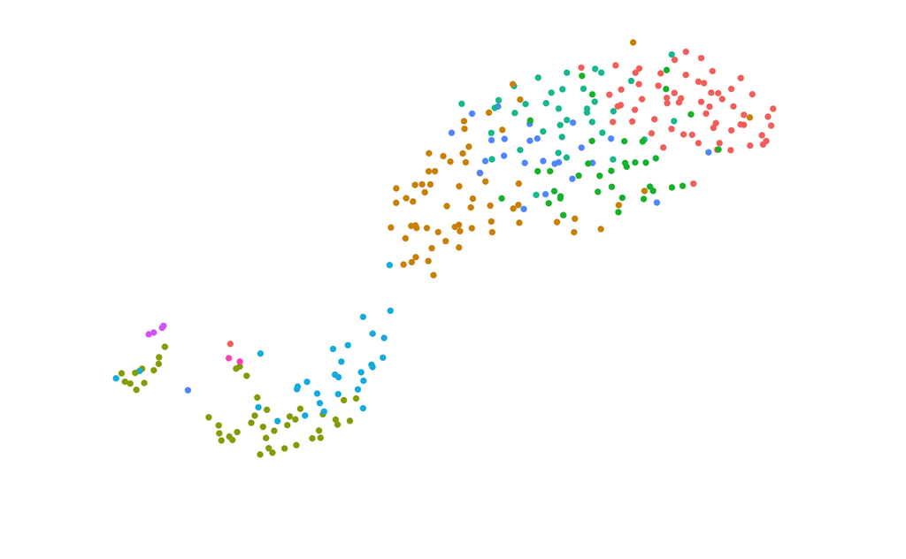

```r
DimPlot(data, reduction = 'rna.umap')
```

### ADT only clustering of all cells

```r
DefaultAssay(data) <- 'ADT'
VariableFeatures(data) <- rownames(data[["ADT"]])
data <- NormalizeData(data, normalization.method = 'CLR', margin = 2) %>%
  ScaleData() %>% RunPCA(reduction.name = 'apca', dims = 1:10)
```

```
Normalizing across cells
```

[output not shown]

[output cut: 249 more lines]

[output not shown]

```
The following 7 features requested have zero variance (running reduction without them): CD27.1, CD69.1, CD137, CD197, CD278, CD335, HLA-DRYou're computing too large a percentage of total singular values, use a standard svd instead.did not converge--results might be invalid!; try increasing work or m…
Positive:  CD14.1, CD15, CD56, CD16, IgG1, TIGIT.1, CD25, IgG2a, CD8a, CD19.1
       PD-1, IgG2b
Negative:  CD3, CD127, CD4.1, CD45RA, CD34.1, CD28.1, CD274.1, CD20, CD86.1, CD62L
       CD80.1, CD11b
PC_ 2
Positive:  CD45RO, CD25, CD4.1, PD-1, TIGIT.1, CD127, CD3, CD62L, CD14.1, CD80.1
       IgG1, CD86.1
Negative:  CD45RA, CD34.1, CD8a, CD56, CD19.1, CD16, CD274.1, CD20, IgG2a, CD15
       IgG2b, CD28.1
PC_ 3
Positive:  IgG1, CD4.1, CD15, CD19.1, CD14.1, IgG2a, IgG2b, CD20, CD45RA, CD28.1
       CD11b, CD62L
Negative:  CD8a, TIGIT.1, CD16, CD56, CD45RO, PD-1, CD34.1, CD3, CD80.1, CD25
       CD86.1, CD274.1
PC_ 4
Positive:  CD19.1, CD25, CD34.1, CD86.1, CD45RO, CD62L, CD8a, CD80.1, IgG1, CD11b
       CD14.1, CD20
Negative:  CD274.1, CD56, CD15, CD3, CD28.1, CD16, CD4.1, IgG2a, CD127, IgG2b
       PD-1, TIGIT.1
PC_ 5
Positive:  CD56, CD20, CD4.1, CD16, TIGIT.1, CD19.1, CD45RA, CD25, IgG2a, CD86.1
       CD80.1, PD-1
Negative:  CD8a, IgG2b, CD127, CD14.1, CD28.1, CD3, CD45RO, CD15, IgG1, CD11b
       CD34.1, CD62L
Cannot add objects with duplicate keys (offending key: PC_), setting key to 'apca_'
```

```r
data <- FindNeighbors(data, reduction = "apca", dims = 1:10)
data <- FindClusters(data, graph.name = "ADT_snn", resolution = 2, verbose = FALSE)
data <- RunUMAP(data, reduction = 'apca', dims = 1:10,
              reduction.name = 'adt.umap', reduction.key = 'adtUMAP_')
```

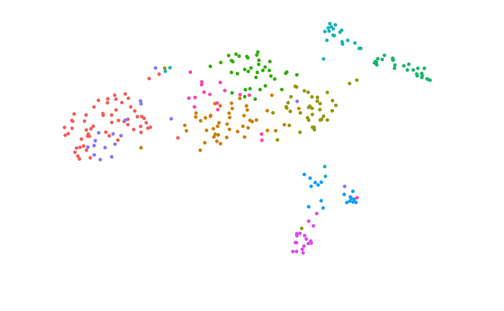

```r
DimPlot(data, reduction = 'adt.umap')
```

### Multimodal clustering of all cells

```r
data <- FindMultiModalNeighbors(
  data, reduction.list = list("pca", "apca"),
  dims.list = list(1:20, 1:10), modality.weight.name = "RNA.weight"
)
```

```
Calculating cell-specific modality weights
Finding 20 nearest neighbors for each modality.
```

[output not shown]

```
Calculating kernel bandwidths
```

[output not shown]

```
The number of provided modality.weight.name is not equal to the number of modalities. RNA.weight ADT.weight are used to store the modality weightsFinding multimodal neighbors
```

[output not shown]

```
Constructing multimodal KNN graph
Constructing multimodal SNN graph
```

```r
data <- RunUMAP(data, nn.name = "weighted.nn", reduction.name = "wnn.umap", reduction.key = "wnnUMAP_")
data <- FindClusters(data, graph.name = "wsnn", algorithm = 3, resolution = 2, verbose = FALSE)
```

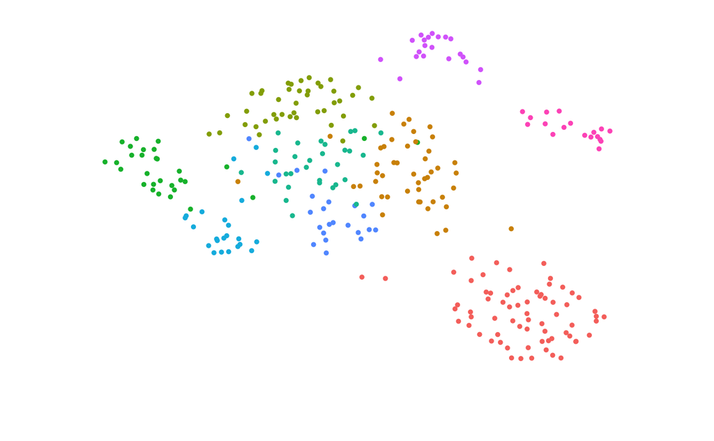

```r
DimPlot(data, reduction = 'wnn.umap', label = TRUE, repel = TRUE)
```

[figure not shown]

```r
FeaturePlot(data, features = c("adt_CD3","rna_CD3E"), reduction = 'wnn.umap')
```

## Analysis of T-cell subset

### Subset to T-cells

```r
data.tcell <- subset(data, seurat_clusters %in% 1:7)
```

### RNA only clustering of T-cells

```r
DefaultAssay(data.tcell) <- 'RNA'
data.tcell <- NormalizeData(data.tcell) %>% FindVariableFeatures() %>% ScaleData() %>% RunPCA(reduction.name = "pca.tcell")
```

```
pseudoinverse used at -2.0314neighborhood radius 0.30103reciprocal condition number  5.3542e-15Calculating feature variances of standardized and clipped values

PC_ 1
Positive:  NKG7, KLRD1, CCL4, CCL5, GZMB, FCGR3A, GZMA, CST7, MYO1F, FGFBP2
       KLRG1, HOPX, XCL2, KLRF1, ACTN4, A2M-AS1, SPON2, CCL4L2, CEBPD, EOMES
       RHOC, GZMH, CD160, CXXC5, MATK, FCRL6, TTC38, MIAT, GNLY, TRGC2
Negative:  RPS12, TPT1, EEF1A1, RPL23, RPS6, RPS29, LTB, RPS2, RPS20, RPS11
       EEF1B2, RPL36A, TMSB10, RPLP1, RPS18, IL7R, FOXP1, LEF1, RCAN3, RPL27A
       MT-ND3, RPL13A, TMEM123, ADD3, NAP1L1, FHIT, MAL, ATRX, BCL11B, NUCKS1
PC_ 2
Positive:  RPS2, RPS12, RPS6, RPLP1, RPS29, MT-ND3, EEF1A1, TMSB10, RPL36A, EEF1B2
       ACTB, CFL1, ACTG1, PFN1, MT-CO3, GZMA, MYO1F, TXNIP, RPS11, KLRG1
       CD8A, CTSW, TRGC2, ANXA2, CST7, MT-ATP6, SH3BGRL3, FCGR3A, MIAT, KLF2
Negative:  HELZ2, ID1, DUSP6, PLCG2, ABHD11, ZNF90, RRNAD1, AIFM2, AC092428.1, LPP
       SLC12A7, FAM43A, NFATC2, GALNT10, FGR, GNLY, DGKQ, TRPM7, SPON2, CEBPD
       RGS2, LTBP4, AC025171.3, SLC66A3, AMZ2, TTC32, FAM217B, CASP8AP2, SPEN, RAB29
PC_ 3
Positive:  KLRC4, TRGC1, LINC002481, CLIC3, CEBPD, RAB27B, ERICH6-AS1, FCRLB, AP001816.1, FCER1G
       EFHD2, GNLY, HARS2, BATF, KLRB1, ADAM8, AKT1S1, WDR48, HEATR6, EPS8L2
       KLB, ANO10, C1RL, STX2, YES1, CD160, AC253572.2, TULP3, LINC00672, PRR5
Negative:  CCL4L2, EOMES, GZMH, TTC38, FCRL6, LAIR2, MIAT, IFNG, TNF, PYHIN1
       PATL2, AL035701.1, CACNA2D4, POMC, TRAPPC13, GSE1, RAP1GAP2, NFAT5, TRGC2, ATG4D
       AC093010.2, ZNF518A, ARRDC1-AS1, LAIR1, VPS72, SYCP2, FGR, SLC35E3, MTSS1, IGF2R
PC_ 4
Positive:  ACTG1, PFN1, DUSP1, JUNB, FTL, RPLP1, RPS12, EEF1A1, ZFP36, ACTB
       TRAC, DUSP2, KLF2, CORO1A, AREG, ZNF341, HSPB1, TSC22D3, CTSO, ANXA1
       SERTAD1, PLIN3, NFKBIA, VIM, STXBP3, STRADA, HCST, PLP2, CXCR4, TOB1
Negative:  MALAT1, BCL11B, RASGRP1, RIPOR2, AC004687.1, OGT, SHPRH, BCL2, SLC5A3, FYB1
       ZNF384, RPL23, SYNE2, AGO4, MACF1, STX16, HNRNPU, USP34, ATRX, CELF2
       IL7R, ANKRD11, ERBIN, DOCK7, GABPB2, NUTM2A-AS1, TNRC6B, CEP350, ZFAND4, C10orf88
PC_ 5
Positive:  KLRF1, AL355816.2, LCORL, NPLOC4, ERICH6-AS1, AC004687.1, FCGR3A, ZNF23, NCOR2, AP001816.1
       GABPB1-AS1, PARP8, IKZF5, ZNF335, ABI1, C12orf43, PPM1N, FCRLB, CST7, TIMP1
       TEF, SHPRH, CDADC1, SP140, TMX3, CLIC3, NDUFAF3, MT2A, HPGD, HLA-F-AS1
Negative:  JUNB, JUN, FOS, RTKN2, MBOAT1, TRDC, FOSB, MCAT, ZNF862, DUSP1
       IDS, AC104695.4, KLF2, H3F3B, ZNF331, GZMK, IER2, CYCS, NFKBIA, MZF1-AS1
       WASHC2C, PPP1R15A, BTG2, TSC22D3, GABPB2, TUBA1A, SRSF7, PLEK, SSH3, DUSP5
Cannot add objects with duplicate keys (offending key: PC_), setting key to 'pca.tcell_'
```

```r
data.tcell <- FindNeighbors(data.tcell, reduction = "pca.tcell", dims = 1:10)
data.tcell <- FindClusters(data.tcell, resolution = 2, verbose = FALSE)
data.tcell <- RunUMAP(data.tcell, reduction = 'pca.tcell', dims = 1:10, assay = 'RNA',
              reduction.name = 'rna.tcell.umap', reduction.key = 'rnaTcellUMAP_')
```

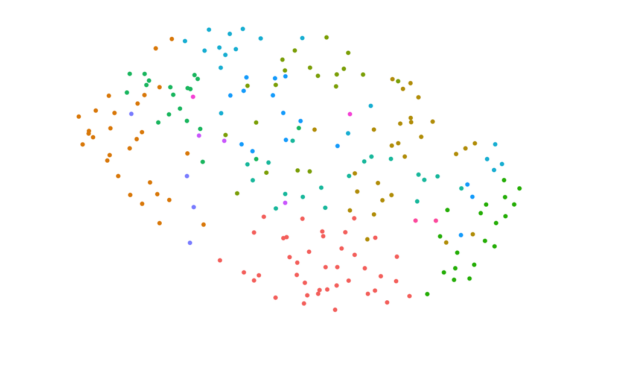

```r
DimPlot(data.tcell, reduction = 'rna.tcell.umap')
```

### ADT only clustering of T-cells

```r
DefaultAssay(data.tcell) <- 'ADT'
VariableFeatures(data.tcell) <- rownames(data.tcell[["ADT"]])
data.tcell <- NormalizeData(data.tcell, normalization.method = 'CLR', margin = 2) %>%
  ScaleData() %>% RunPCA(reduction.name = 'apca.tcell', dims = 1:10)
```

```
Normalizing across cells
```

[output not shown]

[output cut: 161 more lines]

[output not shown]

```
The following 9 features requested have zero variance (running reduction without them): CD11b, CD27.1, CD69.1, CD80.1, CD137, CD197, CD278, CD335, HLA-DRYou're computing too large a percentage of total singular values, use a standard svd instead.did not converge--results might be invalid!; try incre…
Positive:  CD56, CD16, CD8a, TIGIT.1, CD45RA, CD34.1, CD14.1, CD274.1, IgG2a, CD15
       CD86.1, IgG2b
Negative:  CD4.1, CD3, CD127, CD45RO, CD19.1, CD28.1, CD62L, IgG1, CD25, PD-1
       CD20
PC_ 2
Positive:  CD45RO, CD16, CD56, CD25, CD28.1, TIGIT.1, CD15, PD-1, CD86.1, CD62L
       CD274.1, CD4.1
Negative:  CD45RA, CD34.1, CD3, IgG2a, CD14.1, IgG2b, CD8a, CD19.1, CD20, CD127
       IgG1
PC_ 3
Positive:  CD4.1, CD25, IgG2a, CD15, CD19.1, CD56, CD45RA, CD20, CD16, TIGIT.1
       CD274.1, PD-1
Negative:  CD8a, CD127, CD45RO, CD28.1, IgG2b, CD34.1, CD14.1, CD3, CD86.1, CD62L
       IgG1
PC_ 4
Positive:  PD-1, CD14.1, CD15, IgG2b, CD8a, CD62L, CD127, IgG2a, CD28.1, CD3
       IgG1, CD25
Negative:  CD34.1, CD86.1, CD4.1, TIGIT.1, CD16, CD56, CD20, CD274.1, CD19.1, CD45RA
       CD45RO
PC_ 5
Positive:  CD14.1, IgG1, CD19.1, CD16, CD4.1, CD56, CD15, CD45RO, CD34.1, CD3
       CD25, PD-1
Negative:  CD20, CD274.1, CD127, IgG2b, CD86.1, TIGIT.1, CD62L, CD28.1, IgG2a, CD8a
       CD45RA
Cannot add objects with duplicate keys (offending key: PC_), setting key to 'apca.tcell_'
```

```r
data.tcell <- RunUMAP(data.tcell, reduction = 'apca.tcell', dims = 1:10, assay = 'ADT',
              reduction.name = 'adt.tcell.umap', reduction.key = 'adtTcellUMAP_')
data.tcell <- FindNeighbors(data.tcell, reduction = "apca.tcell", dims = 1:10)
data.tcell <- FindClusters(data.tcell, graph.name = "ADT_snn", resolution = 2, verbose = FALSE)
data.tcell <- FindClusters(data.tcell, algorithm = 3, resolution = 2, verbose = FALSE)
```

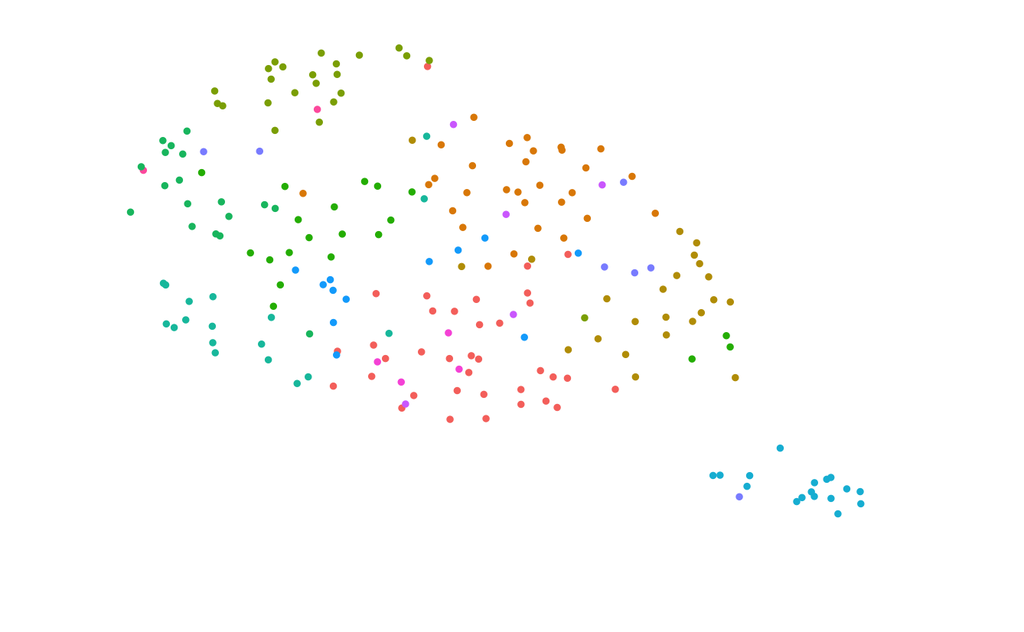

```r
DimPlot(data.tcell, reduction = 'adt.tcell.umap')
```

### Multimodal clustering of T-cells

```r
data.tcell <- FindMultiModalNeighbors(
  data.tcell, reduction.list = list("pca.tcell", "apca.tcell"),
  dims.list = list(1:10, 1:10), modality.weight.name = "RNA.weight"
)
```

```
Calculating cell-specific modality weights
Finding 20 nearest neighbors for each modality.
```

[output not shown]

[output not shown]

[output not shown]

```
The number of provided modality.weight.name is not equal to the number of modalities. RNA.weight ADT.weight are used to store the modality weightsFinding multimodal neighbors
```

[output not shown]

```
Constructing multimodal KNN graph
Constructing multimodal SNN graph
```

```r
data.tcell <- RunUMAP(data.tcell, nn.name = "weighted.nn", reduction.name = "wnn.tcell.umap", reduction.key = "wnnTcellUMAP_")
data.tcell <- FindClusters(data.tcell, graph.name = "wsnn", algorithm = 3, resolution = 2, verbose = FALSE)
```

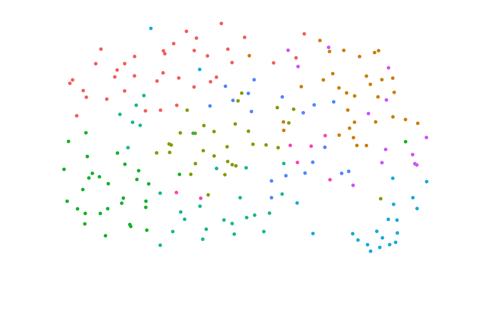

```r
DimPlot(data.tcell, reduction = 'wnn.tcell.umap', label = TRUE, repel = TRUE)
```

```r
saveRDS(data.raw, "pbmc1k_seurat_raw.rds")
saveRDS(data.nonempty, "pbmc1k_seurat_nonempty.rds")
saveRDS(data, "pbmc1k_seurat_filtered.rds")
saveRDS(data.tcell, "pbmc1k_seurat_tcell.rds")
```